# StreamCat Dataset - Welcome

### Looking for data on lakes?

- Data for 378,088 lakes also available from the [LakeCat Dataset](https://www.epa.gov/national-aquatic-resource-surveys/lakecat)

### Updates & Corrections (Latest update - **06 November 2018**)

Be sure to check here for recent updates and corrections to the StreamCat Dataset

### Access StreamCat Data

- Data by HydroRegion
- Data by State
- Data via [EPA WATERS Watershed Characterization Service](https://www.epa.gov/waterdata/waters-watershed-assessment-tracking-environmental-results-system)
  - This is a service providing an HTML report or JSON object listing both standard NHDPlus and StreamCat metrics for a given COMID provided by the user. See HTML Examples in link above, and simply pass a COMID of interest to end of the URL (i.e. pComID=4795168).

### StreamCat Documentation

- A detailed description of the StreamCat Dataset and its development is now available in the [Journal of the American Water Resources Association](http://onlinelibrary.wiley.com/doi/10.1111/1752-1688.12372/abstract).
- **Please include the following citation in any publication or presentation including StreamCat data:** Hill, Ryan A., Marc H. Weber, Scott G. Leibowitz, Anthony R. Olsen, and Darren J. Thornbrugh, 2016. The Stream-Catchment (StreamCat) Dataset: A Database of Watershed Metrics for the Conterminous United States. Journal of the American Water Resources Association (JAWRA) 52:120-128. DOI: 10.1111/1752-1688.12372.
- The Read Me file provides additional detail and important information on how to access and use the StreamCat Dataset.
- The Variable List provides a quick reference of available watershed metrics.
- The Data Dictionary provides a comprehensive description of each watershed metric and how they were derived.
- Information on the steps we followed to acquire geospatial layers to develop the StreamCat Dataset, any manipulations done to those data, and quality assurance steps can be found in Data Processing and Quality Assurance.
- The [StreamCat GitHub](https://github.com/USEPA/StreamCat) page has the latest working versions of StreamCat code and a brief description of each script we used to develop the StreamCat Dataset, including examples of tables used to control the processing of StreamCat with.
- List of publications that have referenced StreamCat (email weber.marc@epa.gov to have us add a publication that is not included)

### FTP Site Structure

- StreamCat
  - Data by HydroRegion
  - Data by State
  - Documentation
    - Read Me
    - **Variable List - Quick Reference** HTML EXCEL
    - Updates - Recent updates to the StreamCat Dataset
    - Data Dictionary - Complete description of source data and metric derivations
    - Metadata
    - Data Processing and Quality Assurance
    - StreamCat Code - [GitHUb](https://github.com/USEPA/StreamCat) (current working code) | Archived Code (original code - no longer used to create StreamCat)

### Data Structure

Data are distributed by US State or NHDPlusV2 Hydrologic Region (see Read Me for additional details). Within States or HydroRegions, data are distributed by major data source (e.g., STATSGO Soils, National Land Cover Database).

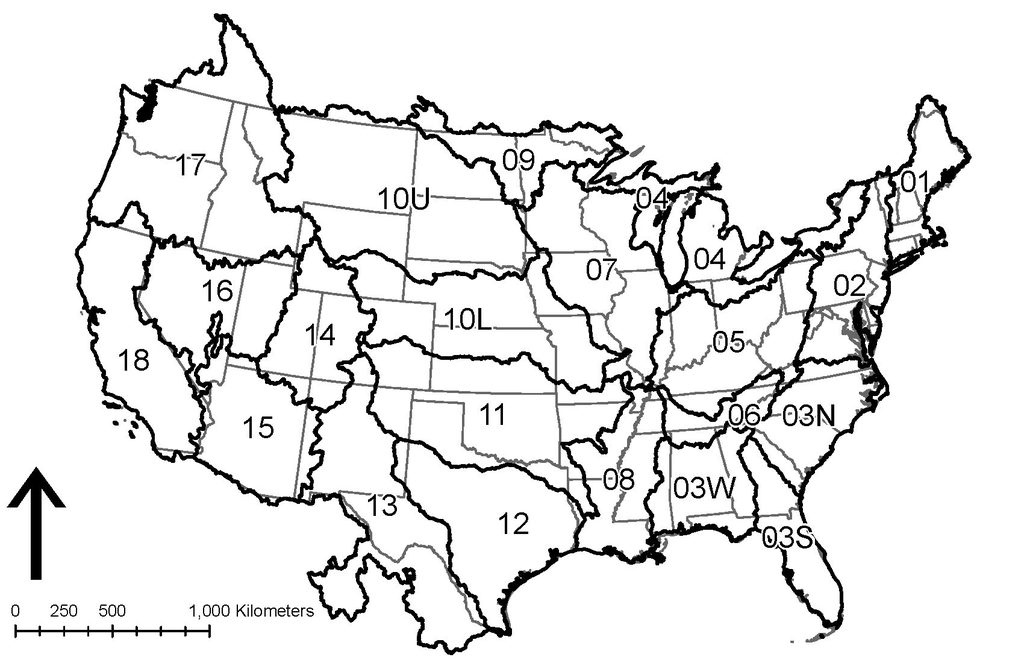

State&HydroRegion